# Bulk ATAC Analysis and BED Preparation

Zack Guo

UCL  
wegmzgu@ucl.ac.uk

September 17, 2026

# Library packages

The workflow uses `DESeq2` for count-based differential accessibility testing, `dplyr` for table manipulation, and `ggplot2` for QC and result plots.

```r
# Load packages for reading featureCounts output, table manipulation,
# differential accessibility testing, and plotting.
library(readr)
library(dplyr)
library(ggplot2)
library(DESeq2)
```

# Aim

This analysis identifies differentially accessible regions (DARs) between hepatocyte and biliary epithelial cell (BEC) bulk ATAC-seq samples. The DAR tables are then converted into BED files for downstream comparison with cHCC-ICC mutation-density patterns.

# Load peak count matrix

The input is a featureCounts table with one row per ATAC peak and six bulk libraries. This section only reads and inspects the table; statistical filtering is performed in the DESeq2 section below.

```r
# featureCounts output for six bulk ATAC-seq samples.
# Read the count table while skipping featureCounts comment lines.
counts_file <- "C:/Bioinfo data/peak_counts_6samples.txt"
raw <- read_tsv(counts_file, comment = "#")

# Inspect the dimensions and first rows before transforming the table.
dim(raw)
```

```
## [1] 22864    12
```

```r
head(raw)
```

| Geneid | Chr | Start | End | Strand | Length | SRR12531987.sorted.bam | SRR12531988.sorted.bam | SRR12531989.sorted.bam | SRR12531990.sorted.bam | SRR12531991.sorted.bam | SRR12531992.sorted.bam |
| --- | --- | --- | --- | --- | --- | --- | --- | --- | --- | --- | --- |
| peak_1 | chr1 | 3514683 | 3515340 | . | 658 | 96 | 161 | 300 | 24 | 93 | 31 |
| peak_2 | chr1 | 3671014 | 3672421 | . | 1408 | 133 | 304 | 503 | 4 | 9 | 7 |
| peak_3 | chr1 | 4332354 | 4332698 | . | 345 | 6 | 8 | 70 | 6 | 0 | 1 |
| peak_4 | chr1 | 4491757 | 4492310 | . | 554 | 22 | 26 | 103 | 2 | 0 | 10 |
| peak_5 | chr1 | 4513903 | 4514291 | . | 389 | 48 | 50 | 148 | 1 | 1 | 1 |
| peak_6 | chr1 | 4571563 | 4572130 | . | 568 | 19 | 105 | 118 | 2 | 4 | 0 |

# Build count matrix and sample metadata

The six count columns are converted into an integer peak-by-sample matrix. The condition order is fixed here: the first three libraries are biliary epithelial cell (BEC) and the last three are hepatocyte replicates.

```r
# These are the six featureCounts columns used in the comparison.
count_cols <- c(
  "SRR12531987.sorted.bam",
  "SRR12531988.sorted.bam",
  "SRR12531989.sorted.bam",
  "SRR12531990.sorted.bam",
  "SRR12531991.sorted.bam",
  "SRR12531992.sorted.bam"
)

# Keep only peak counts and convert them to a matrix for DESeq2.
peak_counts <- as.matrix(raw[, count_cols])

# Use the featureCounts peak identifier as the matrix row name.
rownames(peak_counts) <- raw$Geneid
# Enforce integer storage because DESeq2 expects raw integer counts.
storage.mode(peak_counts) <- "integer"

# Define the condition for each library in the same order as the count matrix.
sample_info <- data.frame(
  row.names = count_cols,
  condition = factor(
    rep(c("BEC", "Hepatocyte"), each = 3),
    levels = c("Hepatocyte", "BEC")
  )
)

sample_info
```

|  | condition |
| --- | --- |
| SRR12531987.sorted.bam | BEC |
| SRR12531988.sorted.bam | BEC |
| SRR12531989.sorted.bam | BEC |
| SRR12531990.sorted.bam | Hepatocyte |
| SRR12531991.sorted.bam | Hepatocyte |
| SRR12531992.sorted.bam | Hepatocyte |

# Peak count overview

This plot checks whether one library has unusually high or low assigned counts. It is a sequencing-depth QC summary, not a differential-accessibility result.

```r
# Sum assigned fragments per library as a basic sequencing-depth QC check.
sample_depth <- data.frame(
  sample = colnames(peak_counts),
  condition = sample_info[colnames(peak_counts), "condition"],
  total_counts = colSums(peak_counts)
)

sample_depth
```

|  | sample | condition | total_counts |
| --- | --- | --- | --- |
| SRR12531987.sorted.bam | SRR12531987.sorted.bam | BEC | 7736839 |
| SRR12531988.sorted.bam | SRR12531988.sorted.bam | BEC | 13579918 |
| SRR12531989.sorted.bam | SRR12531989.sorted.bam | BEC | 14838875 |
| SRR12531990.sorted.bam | SRR12531990.sorted.bam | Hepatocyte | 19625447 |
| SRR12531991.sorted.bam | SRR12531991.sorted.bam | Hepatocyte | 18227879 |
| SRR12531992.sorted.bam | SRR12531992.sorted.bam | Hepatocyte | 23656757 |

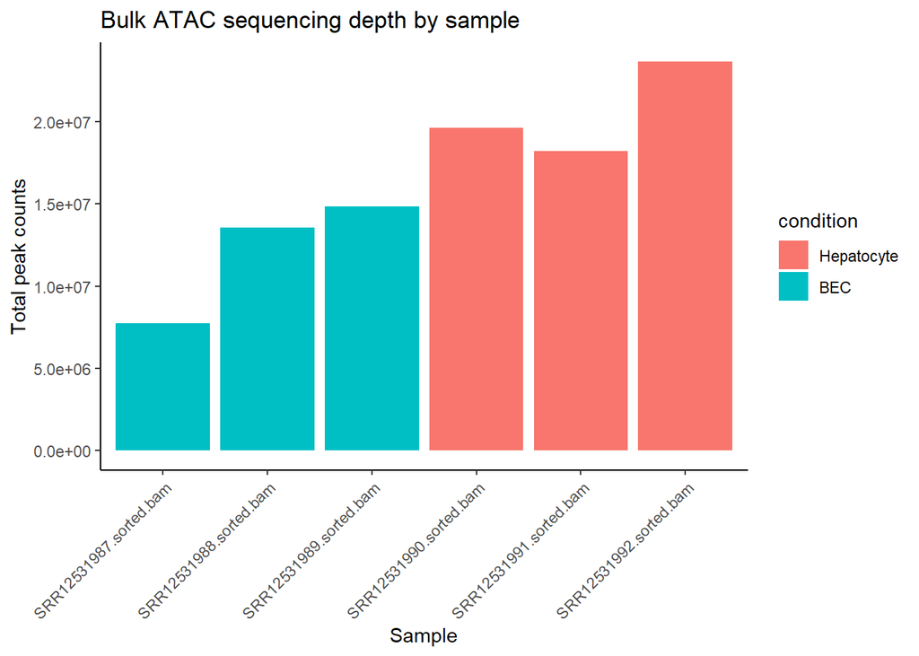

```r
ggplot(sample_depth, aes(x = sample, y = total_counts, fill = condition)) +
  geom_col() +
  theme_classic() +
  theme(axis.text.x = element_text(angle = 45, hjust = 1)) +
  labs(
    title = "Bulk ATAC sequencing depth by sample",
    x = "Sample",
    y = "Total peak counts"
  )
```

# Differential accessibility analysis

DESeq2 models the integer peak counts with a negative-binomial model. The two pre-filters remove peaks with little evidence across all libraries. The contrast is `BEC - Hepatocyte`: positive log2 fold change means higher accessibility in BEC, while negative values mean higher accessibility in hepatocytes.

```r
# Build the DESeq2 object from raw peak counts and sample metadata.
dds <- DESeqDataSetFromMatrix(
  countData = peak_counts,
  colData = sample_info,
  design = ~ condition
)

# Remove peaks with almost no counts before model fitting.
dds <- dds[rowSums(counts(dds)) >= 10, ]
dds <- estimateSizeFactors(dds)
dds <- dds[rowMeans(counts(dds, normalized = TRUE)) >= 5, ]

# Fit the negative-binomial model and estimate dispersion for each peak.
dds <- DESeq(dds)

# Extract the BEC-versus-hepatocyte contrast. Positive log2FC means higher
# accessibility in BEC; negative log2FC means higher accessibility in hepatocytes.
# Positive log2FoldChange means higher accessibility in BEC than hepatocyte.
res <- results(dds, contrast = c("condition", "BEC", "Hepatocyte"))

summary(res)
```

```
##
## out of 19935 with nonzero total read count
## adjusted p-value < 0.1
## LFC > 0 (up)       : 3917, 20%
## LFC < 0 (down)     : 1872, 9.4%
## outliers [1]       : 1, 0.005%
## low counts [2]     : 0, 0%
## (mean count < 5)
## [1] see 'cooksCutoff' argument of ?results
## [2] see 'independentFiltering' argument of ?results
```

# Annotate peaks with genomic coordinates

The statistical result is joined back to the original peak coordinates using the featureCounts `Geneid`/`peak_id` key, making each result usable downstream.

```r
# Convert DESeq2 results to a table and attach the original genomic coordinates.
# Set the adjusted-p-value and effect-size cutoffs before assigning classes.
padj_cutoff <- 0.05
log2fc_cutoff <- 1

res_df <- as.data.frame(res)
res_df$peak_id <- rownames(res_df)

coord_info <- raw %>%
  dplyr::select(Geneid, Chr, Start, End) %>%
  dplyr::rename(
    peak_id = Geneid,
    chrom = Chr,
    chromStart = Start,
    chromEnd = End
  )

res_annotated <- left_join(res_df, coord_info, by = "peak_id") %>%
  dplyr::select(
    peak_id,
    chrom,
    chromStart,
    chromEnd,
    baseMean,
    log2FoldChange,
    lfcSE,
    stat,
    pvalue,
    padj
  ) %>%
  mutate(
    significance = case_when(
      padj < padj_cutoff & log2FoldChange > log2fc_cutoff ~ "Biliary-associated",
      padj < padj_cutoff & log2FoldChange < -log2fc_cutoff ~ "Hepatocyte-associated",
      TRUE ~ "Not significant"
    )
  )

head(res_annotated)
```

|  | peak_id | chrom | chromStart | chromEnd | baseMean | log2FoldChange | lfcSE | stat | pvalue | padj | significance |
| --- | --- | --- | --- | --- | --- | --- | --- | --- | --- | --- | --- |
| 1 | peak_1 | chr1 | 3514683 | 3515340 | 101.224788 | -2.0637728 | 0.2414698 | -8.5467110 | 1.266458e-17 | 1.941967e-14 | Hepatocyte-associated |
| 2 | peak_2 | chr1 | 3671014 | 3672421 | 45.634806 | 1.4516187 | 0.4274997 | 3.3956019 | 6.847787e-04 | 6.493995e-03 | Biliary-associated |
| 3 | peak_3 | chr1 | 4332354 | 4332698 | 9.075381 | -1.3435523 | 1.4147066 | -0.9497038 | 3.422628e-01 | 5.454642e-01 | Not significant |
| 4 | peak_4 | chr1 | 4491757 | 4492310 | 15.098980 | -0.9590755 | 1.1868232 | -0.8081030 | 4.190313e-01 | 6.199324e-01 | Not significant |
| 5 | peak_5 | chr1 | 4513903 | 4514291 | 10.894174 | 2.2616885 | 0.9753662 | 2.3188097 | 2.040536e-02 | 7.714022e-02 | Not significant |
| 6 | peak_6 | chr1 | 4571563 | 4572130 | 11.531682 | 1.2644060 | 0.9077341 | 1.3929255 | 1.636423e-01 | 3.377558e-01 | Not significant |

# Define significant DARs

DARs require both an adjusted-p-value threshold and an effect-size threshold. The direction is retained in the class label for the downstream BED files.

```r
biliary_dars <- res_annotated %>%
  filter(significance == "Biliary-associated")

hepatocyte_dars <- res_annotated %>%
  filter(significance == "Hepatocyte-associated")

dar_summary <- data.frame(
  group = c("Biliary-associated DARs", "Hepatocyte-associated DARs"),
  n_peaks = c(nrow(biliary_dars), nrow(hepatocyte_dars))
)

dar_summary
```

| group | n_peaks |
| --- | --- |
| Biliary-associated DARs | 2951 |
| Hepatocyte-associated DARs | 1217 |

```r
write.csv(
  biliary_dars,
  file = "C:/Bioinfo data/DARs_for_billiary.csv",
  row.names = FALSE
)

write.csv(
  hepatocyte_dars,
  file = "C:/Bioinfo data/DARs_for_hepatocyte.csv",
  row.names = FALSE
)
```

# DAR summary plots

These plots show the number of significant regions and the full differential- accessibility result. The same `significance` field is used for both outputs.

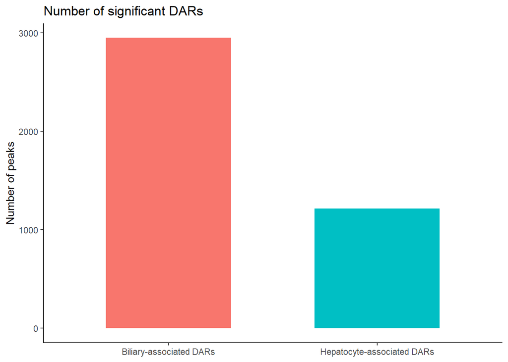

```r
# Plot the number of significant regions in each direction.
ggplot(dar_summary, aes(x = group, y = n_peaks, fill = group)) +
  geom_col(width = 0.6) +
  theme_classic() +
  guides(fill = "none") +
  labs(
    title = "Number of significant DARs",
    x = NULL,
    y = "Number of peaks"
  )
```

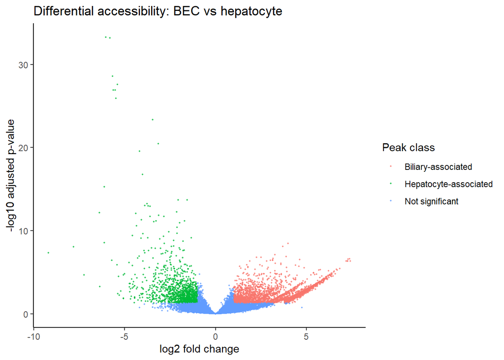

```r
# Plot all tested peaks, coloured using the same significance class as above.
ggplot(
  res_annotated,
  aes(
    x = log2FoldChange,
    y = -log10(padj),
    colour = significance
  )
) +
  geom_point(size = 0.4, alpha = 0.7) +
  theme_classic() +
  labs(
    title = "Differential accessibility: BEC vs hepatocyte",
    x = "log2 fold change",
    y = "-log10 adjusted p-value",
    colour = "Peak class"
  )
```

# Prepare BED files

Source featureCounts/SAF coordinates are 1-based and closed, whereas BED uses 0-based, half-open intervals, so the start coordinate is shifted by one base.

The DAR tables are converted into BED-format genomic intervals. The `billiary` spelling is kept in file names to match the original project files.

```r
# Define paths for DAR CSV artifacts and BED files.
biliary_dar_csv <- "C:/Bioinfo data/DARs_for_billiary.csv"
hepatocyte_dar_csv <- "C:/Bioinfo data/DARs_for_hepatocyte.csv"

biliary_bed <- "C:/Bioinfo data/billiary.bed"
hepatocyte_bed <- "C:/Bioinfo data/hepatocyte.bed"

# These human-coordinate files retain their original names from before the
# bulk ATAC sample labels were corrected. Their biological identities are
# therefore swapped here: the old biliary-named file is hepatocyte-associated,
# and the old hepatocyte-named file is biliary-associated.
hepatocyte_human_bed <- "C:/Bioinfo data/billiaryhuman.bed"
biliary_human_bed <- "C:/Bioinfo data/hepatocytehuman.bed"
all_human_bed <- "C:/Bioinfo data/allhuman.bed"

make_bed_from_dars <- function(dar, output_bed) {
  # Join significant peak IDs to genomic coordinates.
  bed <- dar %>%
    dplyr::select(peak_id) %>%
    left_join(coord_info, by = "peak_id") %>%
    filter(!is.na(chromStart)) %>%
    transmute(
      # Convert 1-based closed SAF coordinates to 0-based half-open BED starts.
      chrom = chrom,
      chromStart = as.integer(chromStart) - 1L,
      chromEnd = as.integer(chromEnd),
      peak_id = peak_id
    )

  write.table(
    bed,
    file = output_bed,
    sep = "\t",
    quote = FALSE,
    row.names = FALSE,
    col.names = FALSE
  )

  bed
}

biliary_bed_df <- make_bed_from_dars(
  dar = biliary_dars,
  output_bed = biliary_bed
)

hepatocyte_bed_df <- make_bed_from_dars(
  dar = hepatocyte_dars,
  output_bed = hepatocyte_bed
)

bed_summary <- data.frame(
  bed_file = c(biliary_bed, hepatocyte_bed),
  n_regions = c(nrow(biliary_bed_df), nrow(hepatocyte_bed_df))
)

bed_summary
```

| bed_file | n_regions |
| --- | --- |
| C:/Bioinfo data/billiary.bed | 2951 |
| C:/Bioinfo data/hepatocyte.bed | 1217 |

# Human-coordinate BED files

The human-coordinate files below came from an external liftOver step and are used for overlap with human cHCC-ICC mutation data. Because their filenames retain the previous reversed lineage labels, they are assigned to their corrected biological identities above.

```r
read_bed <- function(path) {
  # Read a three-column human-coordinate BED as a plain table for summaries.
  read.table(path, header = FALSE, stringsAsFactors = FALSE)
}

# These files were generated by an external liftOver step.
hepatocyte_human <- read_bed(hepatocyte_human_bed)
biliary_human <- read_bed(biliary_human_bed)

human_bed_summary <- data.frame(
  lineage = c("Hepatocyte-associated", "Biliary-associated"),
  bed_file = c(hepatocyte_human_bed, biliary_human_bed),
  n_regions = c(nrow(hepatocyte_human), nrow(biliary_human))
)

human_bed_summary
```

| lineage | bed_file | n_regions |
| --- | --- | --- |
| Hepatocyte-associated | C:/Bioinfo data/billiaryhuman.bed | 1020 |
| Biliary-associated | C:/Bioinfo data/hepatocytehuman.bed | 2704 |

# Combine human-coordinate DARs

The two lifted DAR sets are combined into one reference BED for distribution checks. The individual H and biliary files remain separate for notebook 05.

```r
# Combine the two lifted DAR sets for the chromosome distribution check.
all_human <- unique(rbind(hepatocyte_human, biliary_human))

write.table(
  all_human,
  file = all_human_bed,
  sep = "\t",
  quote = FALSE,
  row.names = FALSE,
  col.names = FALSE
)

combined_summary <- data.frame(
  bed_file = all_human_bed,
  n_regions = nrow(all_human)
)

combined_summary
```

| bed_file | n_regions |
| --- | --- |
| C:/Bioinfo data/allhuman.bed | 3724 |

# Genomic distribution overview

This is a simple chromosome-level sanity check on the lifted intervals. It does not assess liftOver success, unmapped peaks, or one-to-many mappings.

```r
# Count the combined lifted intervals by chromosome.
human_chr_summary <- data.frame(
  chromosome = all_human[[1]]
) |>
  table()

human_chr_summary
```

```
## chromosome
##                  chr1                 chr10                 chr11
##                   378                   187                   223
## chr11_gl000202_random                 chr12                 chr13
##                     1                   183                    99
##                 chr14                 chr15                 chr16
##                   118                   111                   115
##                 chr17                 chr18                 chr19
##                   144                    89                   124
##                  chr2                 chr20                 chr21
##                   259                    99                    44
##                 chr22                  chr3                  chr4
##                    78                   220                   197
##                  chr5                  chr6                  chr7
##                   244                   225                   175
##                  chr8                  chr9                  chrM
##                   168                   160                     5
##                  chrX                  chrY
##                    77                     1
```

# Interpretation

This workflow first defines hepatocyte- and biliary-associated DARs from bulk ATAC-seq peak counts. The source DARs are then written as BED intervals and linked to the existing liftover-derived human-coordinate BED files.

The final `allhuman.bed` file is retained as a combined reference for the chromosome-distribution check. Notebook 05 reads the corrected hepatocyte and biliary human-coordinate BED files separately for mutation-overlap analysis. Because these files come from liftOver, they should be interpreted as mapped regulatory intervals rather than a complete one-to-one representation of the original peak set.